# Capstone Milestone Report

### Summary

The goal of this project is just to display that you’ve gotten used to working with the data and that you are on track to create your prediction algorithm. This report explains only the major features of the data you have identified and briefly summarize your plans for creating the prediction algorithm and Shiny app in a way that would be understandable to a non-data scientist manager. The motivation for this project is to:

1. Demonstrate that you’ve downloaded the data and have successfully loaded it in.
2. Create a basic report of summary statistics about the data sets.
3. Report any interesting findings that you amassed so far.
4. Get feedback on your plans for creating a prediction algorithm and Shiny app.

### Data

```r
library(stringi)
library(xtable)
library(knitr)
library(tm)
library(quanteda)
library(wordcloud)
library(ggplot2)
library(data.table)

setwd("C:/Users/Propietario/Desktop/Capstone")

blogs <- readLines("en_US.blogs.txt", encoding = "UTF-8", skipNul = TRUE)
news <- readLines("en_US.news.txt", encoding = "UTF-8", skipNul = TRUE)
twitter <- readLines("en_US.Twitter.txt", encoding = "UTF-8", skipNul = TRUE)

convertion <- 1024^2
blogs_size <- file.size('en_US.blogs.txt')/ convertion
news_size <- file.size('en_US.news.txt')/ convertion
twitter_size <- file.size('en_US.twitter.txt')/ convertion

blogs_linec <- length(blogs)
news_linec <- length(news)
twitter_linec <- length(twitter)

blogs_wordc <- sum(stri_count_words(blogs))
news_wordc <- sum(stri_count_words(news))
twitter_wordc <- sum(stri_count_words(twitter))

summary <- data.frame(c(blogs_size, news_size, twitter_size), c(blogs_linec, news_linec, twitter_linec), c(blogs_wordc, news_wordc, twitter_wordc))
row.names(summary) <- c('Blogs','News','Twitter')
nms <- c('Size', 'Line count', 'Word count')
setnames(summary, nms)
summary
```

```
            Size Line count Word count
Blogs   200.4242     899288   37546239
News    196.2775      77259    2674536
Twitter 159.3641    2360148   30093413
```

### Corpus

Creating corpus using the three data sets.

```r
sample <- 10000
blogs <- readLines("en_US.blogs.txt", sample, encoding = "UTF-8", skipNul = TRUE)
news <- readLines("en_US.news.txt", sample, encoding = "UTF-8", skipNul = TRUE)
twitter <- readLines("en_US.Twitter.txt", sample, encoding = "UTF-8", skipNul = TRUE)
corpus <- Corpus(VectorSource(c(blogs, news, twitter)))
```

### Data cleaning

Managing text data:

```r
Tokens1 <- tokens(
      x = tolower(corpus), what = c("word"),
      remove_punct = TRUE,
      remove_twitter = TRUE,
      remove_numbers = TRUE,
      remove_hyphens = TRUE,
      remove_url = TRUE
)
Tokens2 <- tokens_remove(tokens(Tokens1), stopwords("english"))
stop_words <- tokens_wordstem(Tokens2, language = "english")
corpus2 <- Corpus(VectorSource(stop_words))
```

### Tokenization

With the data cleaned we can proceed into it’s analysis by “tokenizating” the data in 3 schemes:

- Unigram
- Bigram
- Trigram

```r
bi_gram <- tokens_ngrams(stop_words, n = 2)
tri_gram <- tokens_ngrams(stop_words, n = 3)

uni_DFM <- dfm(stop_words)
bi_DFM <- dfm(bi_gram)
tri_DFM <- dfm(tri_gram)

uni_DFM <- dfm_trim(uni_DFM, 3)
bi_DFM <- dfm_trim(bi_DFM, 3)
tri_DFM <- dfm_trim(tri_DFM, 3)

sums_U <- colSums(uni_DFM)
sums_B <- colSums(bi_DFM)
sums_T <- colSums(tri_DFM)

uni_words <- data.table(word_1 = names(sums_U), count = sums_U)

bi_words <- data.table(
      word_1 = sapply(strsplit(names(sums_B), "_", fixed = TRUE), '[[', 1),
      word_2 = sapply(strsplit(names(sums_B), "_", fixed = TRUE), '[[', 2),
      count = sums_B)

tri_words <- data.table(
      word_1 = sapply(strsplit(names(sums_T), "_", fixed = TRUE), '[[', 1),
      word_2 = sapply(strsplit(names(sums_T), "_", fixed = TRUE), '[[', 2),
      word_3 = sapply(strsplit(names(sums_T), "_", fixed = TRUE), '[[', 3),
      count = sums_T)


uni_words <- uni_words[order(count, decreasing = TRUE)][1:20,]
bi_words <- bi_words[order(count, decreasing = TRUE)][1:20,]
tri_words <- tri_words[order(count, decreasing = TRUE)][1:20,]
```

### Wordcloud

Since we are using text data, a good option its to make a wordcloud to have a better understanding of the most repeated words in the data.

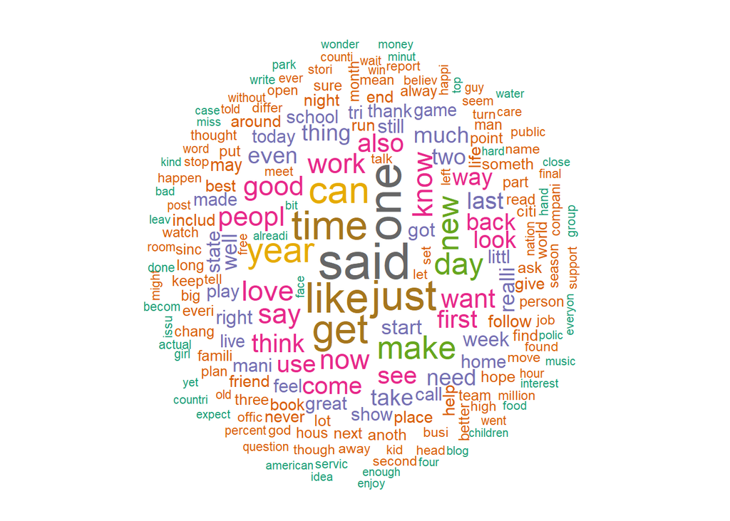

```r
wordcloud(corpus2, max.words = 200, random.order = FALSE,
           rot.per = 0.1, scale = c(2.9, 0.4), use.r.layout = FALSE,
           colors = brewer.pal(8, "Dark2"))
```

### Histograms

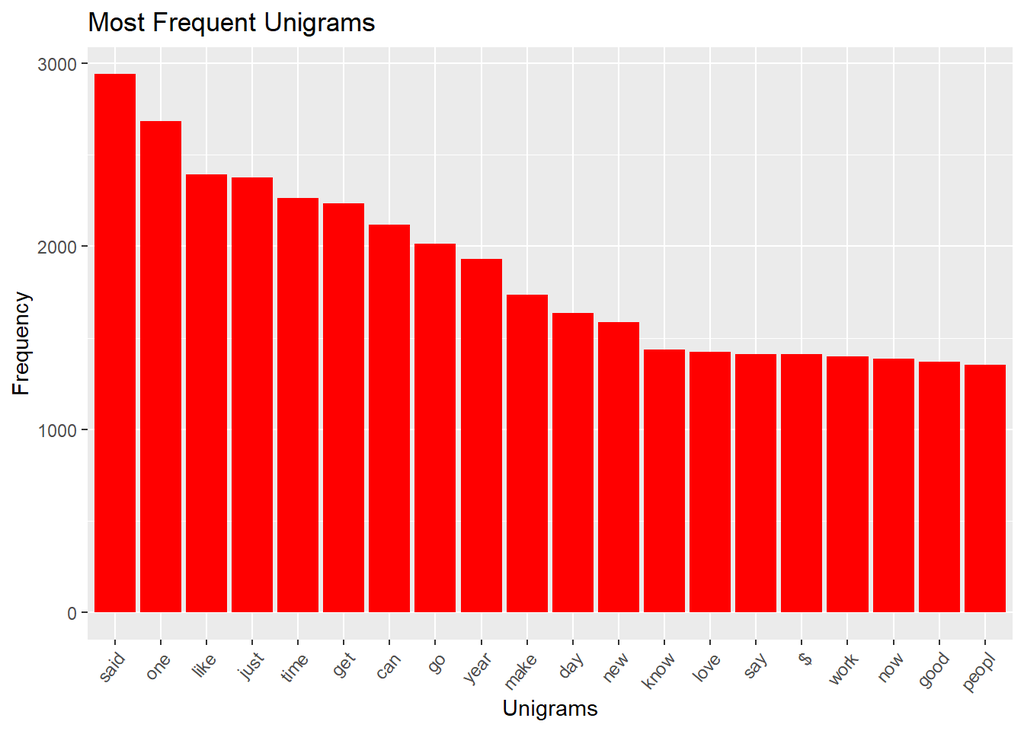

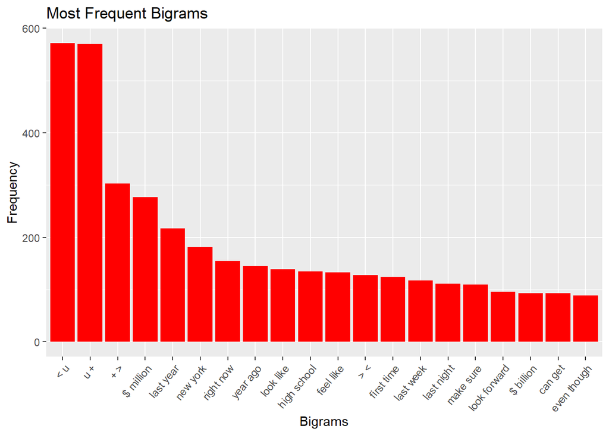

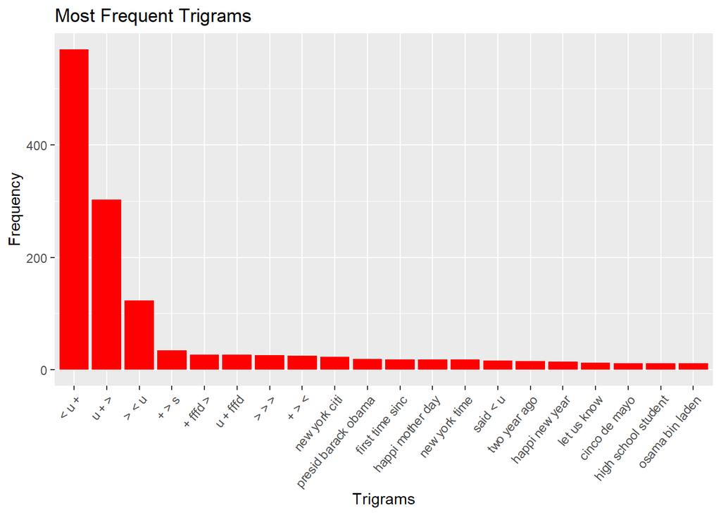

```r
hist1 <- ggplot(uni_words, aes(x=reorder(word_1, -count),y=count)) +
      geom_bar(stat="identity", fill="red") +
      ggtitle(paste("Most Frequent Unigrams")) +
      xlab("Unigrams") + ylab("Frequency") +
      theme(axis.text.x=element_text(angle=50, hjust=1))
hist2 <- ggplot(bi_words, aes(x=reorder(paste(word_1,word_2), -count), y=count)) +
      geom_bar(stat="identity", fill="red") +
      ggtitle(paste("Most Frequent Bigrams")) +
      xlab("Bigrams") + ylab("Frequency") +
      theme(axis.text.x=element_text(angle=50, hjust=1))
hist3 <- ggplot(tri_words, aes(x=reorder(paste(word_1,word_2,word_3), -count), y=count)) +
      geom_bar(stat="identity", fill="red") +
      ggtitle(paste("Most Frequent Trigrams")) +
      xlab("Trigrams") + ylab("Frequency") +
      theme(axis.text.x=element_text(angle=50, hjust=1))
hist1;hist2;hist3
```

### Conclusions and recomendations

The next step is to bluid the shinny app and deploy the algorithm in it with an user-interface to interact with our predictive model to predict the next word.